# Anaerobic Digestion - costs and performance parameters form the literature

This notebook aims to explicitly show how data was gathered and handeled for the identification of key engineering parameters.

```python
import numpy as np
import pandas as pd
from matplotlib import pyplot as plt
import matplotlib

%matplotlib inline

#np.set_printoptions(precision=3, suppress  = True)
```

## Economic considerations

The operating cost is a significant part of the total cost of the biogas cleaning process. It is therfore useful to annualize the investment cost in order to arrive to the total anual cost or TOTEX to be able to accuratly compare each scenario.

```python
# Annualization factor tau
i = 0.025 # 2.5% interest rate
n = 20 # years of explooitation 1
Tau = (i*(1+i)**n)/((1+i)**n - 1)
# Source: from the paper by S. Giarola 2018
```

```python
# list of reference and their respective marker
paper = [['IEA 2014','s'], ['DECC 2015', '+'], ['ETRI 2015', '^'], ['IRENA 2012','o']]
# Key Parameters to be associated with each paper
# N.b. q refers to energy flow, v refers to gas flow rate
TOTEX_q = [[],[],[],[]]
TOTEX_v = [[],[],[],[]]
CAPEX_q = [[],[],[],[]]
CAPEX_v = [[],[],[],[]]
OPEX_q = [[],[],[],[]]
OPEX_v = [[],[],[],[]]
Size_q = [[],[],[],[]]
Size_v = [[],[],[],[]]
# Toggle save figures
save = False
```

```python
# Some data from other sources used multiple times
LHV_CH4v = 32.573/3.6 #kWh/m^3
# Source: DOI 10.1016/S0360-3199(00)00061-6

CEPCI_2019 = 619.2 # Preliminary value for january 2019

Exchange_Rate_USD = 1.239846 #[USD/EUR] average over the 10 last years
Exchange_Rate_AUD = 1.451752 #[AUD/EUR] average over the 10 last years
Exchange_Rate_GBP = 0.836784 #[GBP/EUR] average over the 10 last years
# source : https://www.ofx.com/en-au/forex-news/historical-exchange-rates/yearly-average-rates/

# Electric efficiency of a CHP unit, from DOI 10.1149/09101.0107ecst
eff_elec_CHP = 0.35 # kW-el/kW-th


# Capital cost fraction dedicated to a CHP unit in a AD + CHP system, from DOI 10.13140/RG.2.1.1502.0883
f_cost_CHP = 0.33 # -
```

```python
# Assumptions in the context of the W2W project

# Biogas volumetric methane fraction on average (MSW, Farm, Land fill)
f_CH4_w2w = 0.56
# Source: PSI’s contributions: Waste2Watts WP1.2

# Capacity Factor
cap_w2w = 0.9 #[opertaing hours/hours/year]
year = 365*24 #[hours/year]

# If not specified operating costs are 5% of Total PLant Costs, i.e.
f_OC = 0.05/1.125 # [-] fraction of Investment Costs
# Source: Karellas, S. 2010
```

```python
# functions
def write_EX(inv, op, S, i, unit):
    if unit == 'energy':
        # in EUR/kW-LHV/year
        TOTEX_q[i] = Tau*inv + op
        # in EUR/kW-LHV
        CAPEX_q[i] = inv
        # in EUR/kW-LHV/year
        OPEX_q[i] = op
        # in kW-LHV
        Size_q[i] = S
    else:
        # in EUR/m^3/h/year
        TOTEX_v[i] = Tau*inv + op
        # in EUR/m^3/h
        CAPEX_v[i] = inv
        # in EUR/m^3/h/year
        OPEX_v[i] = op
        # in m^3/h
        Size_v[i] = S
def print_results(inv,  op, S, unit):
    if unit == 'energy':
        print('Function of energy flow: Cost per kW-LHV of biogas produced:')
    else:
        print('Function of volume flow: Cost per m^3/h of biogas produced:')

    print('specific investment cost: ', ['{:.2f}'.format(i) for i in inv])
    print('specific operating cost: ', ['{:.2f}'.format(i) for i in op])
    print('size: ', ['{:.2f}'.format(i) for i in S])
```

## 1. IEA 2013

**Title** : ETSAP-IEA Technology Brief

**Authors** : Labriet Maryse

**Year of publication** : 2013

**Link** : https://iea-etsap.org/E-TechDS/PDF/P11_BiogasProd_ML_Dec2013_GSOK.pdf

### Data from the present paper

```python
# ~AD Unit
# Total Capital Cost
IC = np.array([5000, 7500]) # 2012-USD/ m^3/h
# Annual Maintenance Cost
OC = np.array([0.02*np.mean(IC), 0.07*np.mean(IC)]) # 2012-USD/ m^3/h /year
# Biogas yied rates
v_biogas = np.array([500, 100]) # m^3/h
```

### Data from other sources

```python
# Economics
CEPCI_ref = 584.6 # value for 2012

# Currency Conversion Factor
C = (CEPCI_2019/CEPCI_ref)/Exchange_Rate_USD
```

### Unit transformation

```python
# paper index
i = 0

# methane yied rate
v_methane = v_biogas*f_CH4_w2w # m^3/h

# energy flow
S_q = v_methane*LHV_CH4v # [kW-LHV] nominal biogas flow
# biogas volume flow
S_v = v_biogas  # [m^3/h]

# Function of energy flow
u = 'energy'
S = S_q
inv = C*np.divide(IC*v_methane,S_q) #[EUR/kW-LHV]
op = C*np.divide(OC*v_methane,S_q) #[EUR/kW-LHV/year]

write_EX(inv, op, S, i, u)
print_results(inv,  op, S, u)


# Function of volume flow
u = 'volume'
S = S_v
inv = C*IC #[EUR/m^3/h ]
op = C*OC #[EUR/m^3/h /year]

write_EX(inv, op, S, i, u)
print_results(inv,  op, S, u)
```

```
Function of energy flow: Cost per kW-LHV of biogas produced:
specific investment cost:  ['472.08', '708.13']
specific operating cost:  ['11.80', '41.31']
size:  ['2533.46', '506.69']
Function of volume flow: Cost per m^3/h of biogas produced:
specific investment cost:  ['4271.44', '6407.16']
specific operating cost:  ['106.79', '373.75']
size:  ['500.00', '100.00']
```

## 2. UK DECC 2015

**Title** : Report for the UK department of energy and climate change

**Authors** : Parsons Brinckerhoff

**Year of publication** : 2015

**Link** : https://assets.publishing.service.gov.uk/government/uploads/system/uploads/attachment_data/file/456187/DECC_Small-Scale_Generation_Costs_Update_FINAL.PDF

### Data from the present paper

```python
# ~AD Unit
# Total Capital Cost min - median - max
IC = np.array([3780, 5953, 8126]) # GBP/kW-el
# Annual Maintenance Cost
OC = np.array([268, 759, 1250]) # GBP/kW-el/year
# Nominal Energy output (average)
q_biogas = np.repeat(155, len(IC))/eff_elec_CHP # kW-th
```

### Data from other sources

```python
# Economics
CEPCI_ref = 556.8 # value for 2015

# Currency Conversion Factor
C = (CEPCI_2019/CEPCI_ref)/Exchange_Rate_GBP
```

### Unit transformation

```python
# paper index
i = 1

# Conversion factor from cost/kW-th to cost/kW-el
C_AD_th = (1 - f_cost_CHP)*eff_elec_CHP

# methane yied rate
v_biogas = q_biogas/f_CH4_w2w/LHV_CH4v # m^3/h

# energy flow
S_q = q_biogas # [kW-LHV] nominal biogas flow
# biogas volume flow
S_v = v_biogas  # [m^3/h]

# Function of energy flow
u = 'energy'
S = S_q
inv = C*C_AD_th*IC #[EUR/kW-LHV]
op = C*C_AD_th*OC #[EUR/kW-LHV/year]

write_EX(inv, op, S, i, u)
print_results(inv,  op, S, u)


# Function of volume flow
u = 'volume'
S = S_v
inv = C*C_AD_th*np.divide(IC*q_biogas, S) #[EUR/m^3/h]
op = C*C_AD_th*np.divide(OC*q_biogas, S) #[EUR/m^3/h/year]

write_EX(inv, op, S, i, u)
print_results(inv,  op, S, u)
```

```
Function of energy flow: Cost per kW-LHV of biogas produced:
specific investment cost:  ['1178.02', '1855.23', '2532.43']
specific operating cost:  ['83.52', '236.54', '389.56']
size:  ['442.86', '442.86', '442.86']
Function of volume flow: Cost per m^3/h of biogas produced:
specific investment cost:  ['5968.93', '9400.27', '12831.61']
specific operating cost:  ['423.19', '1198.52', '1973.85']
size:  ['87.40', '87.40', '87.40']
```

## 3. ETRI 2014

**Title** : Energy Technology Reference Indicator ETRI projections for 2010-2050

**Authors** : Moles, C and Sigfusson, B and Spisto, A and Vallei, M and Weidner, E and Giuntoli, Jacopo and Jäger-Waldau, A and Lacal Arántegui, Roberto and Lazarou, S and Magagna, D and Carlsson, J and Perez Fortes, Maria del Mar and Marco, G. de and Jakubcionis

**Year of publication** : 2014

**ISBN** : 978-92-79-44403-6

### Data from the present paper

```python
# ~AD Unit
# Total Capital Cost min - median - max
IC = np.array([2540, 3880, 6380]) # EUR/kW-th
# Annual Maintenance Cost
OC = 0.041*IC # EUR/kW-th/year
# Nominal Energy output (average)
q_biogas = np.repeat(1000, len(IC))/eff_elec_CHP # kW-el
```

### Data from other sources

```python
# Economics
CEPCI_ref = 567.3 # value for 2013

# Currency Conversion Factor
C = (CEPCI_2019/CEPCI_ref)
```

### Unit transformation

```python
# paper index
i = 2

# Conversion factor from cost/kW-th to cost/kW-el
C_AD_th = (1 - f_cost_CHP)*eff_elec_CHP

# methane yied rate
v_biogas = q_biogas/f_CH4_w2w/LHV_CH4v # m^3/h

# energy flow
S_q = q_biogas # [kW-LHV] nominal biogas flow
# biogas volume flow
S_v = v_biogas  # [m^3/h]

# Function of energy flow
u = 'energy'
S = S_q
inv = C*C_AD_th*IC #[EUR/kW-LHV]
op = C*C_AD_th*OC #[EUR/kW-LHV/year]

write_EX(inv, op, S, i, u)
print_results(inv,  op, S, u)


# Function of volume flow
u = 'volume'
S = S_v
inv = C*C_AD_th*np.divide(IC*q_biogas, S) #[EUR/m^3/h]
op = C*C_AD_th*np.divide(OC*q_biogas, S) #[EUR/m^3/h/year]

write_EX(inv, op, S, i, u)
print_results(inv,  op, S, u)
```

```
Function of energy flow: Cost per kW-LHV of biogas produced:
specific investment cost:  ['650.12', '993.10', '1632.98']
specific operating cost:  ['26.65', '40.72', '66.95']
size:  ['2857.14', '2857.14', '2857.14']
Function of volume flow: Cost per m^3/h of biogas produced:
specific investment cost:  ['3294.11', '5031.95', '8274.18']
specific operating cost:  ['135.06', '206.31', '339.24']
size:  ['563.88', '563.88', '563.88']
```

## 4. IRENA 2012

**Title** : IRENA Renewable Power Generation Costs in 2012: An Overview

**Authors** :

**Year of publication** : 2013

**URL** : https://www.irena.org/-/media/Files/IRENA/Agency/Publication/2013/Overview_Renewable-Power-Generation-Costs-in-2012.pdf?la=en&hash=AD59C4928EE8CBC1418A5C3AD7B04EB63AAF8A86

### Data from the present paper

```python
# ~AD Unit
# Total Capital Cost min - median - max
IC = np.array([2570, 6100]) # EUR/kW-th
# Annual Maintenance Cost
OC = 0.05*IC # EUR/kW-th/year
# Nominal Energy output (average)
q_biogas = np.array([10000, 1000])/eff_elec_CHP # kW-el
```

### Data from other sources

```python
# Economics
CEPCI_ref = 584.6 # value for 2013

# Currency Conversion Factor
C = (CEPCI_2019/CEPCI_ref)/Exchange_Rate_USD
```

### Unit transformation

```python
# paper index
i = 3

# Conversion factor from cost/kW-th to cost/kW-el
C_AD_th = (1 - f_cost_CHP)*eff_elec_CHP

# methane yied rate
v_biogas = q_biogas/f_CH4_w2w/LHV_CH4v # m^3/h

# energy flow
S_q = q_biogas # [kW-LHV] nominal biogas flow
# biogas volume flow
S_v = v_biogas  # [m^3/h]

# Function of energy flow
u = 'energy'
S = S_q
inv = C*C_AD_th*IC #[EUR/kW-LHV]
op = C*C_AD_th*OC #[EUR/kW-LHV/year]

write_EX(inv, op, S, i, u)
print_results(inv,  op, S, u)


# Function of volume flow
u = 'volume'
S = S_v
inv = C*C_AD_th*np.divide(IC*q_biogas, S) #[EUR/m^3/h]
op = C*C_AD_th*np.divide(OC*q_biogas, S) #[EUR/m^3/h/year]

write_EX(inv, op, S, i, u)
print_results(inv,  op, S, u)
```

```
Function of energy flow: Cost per kW-LHV of biogas produced:
specific investment cost:  ['514.85', '1222.02']
specific operating cost:  ['25.74', '61.10']
size:  ['28571.43', '2857.14']
Function of volume flow: Cost per m^3/h of biogas produced:
specific investment cost:  ['2608.70', '6191.85']
specific operating cost:  ['130.43', '309.59']
size:  ['5638.83', '563.88']
```

## Result Display

### Total costs relative to size

```python
# Switch functions for the different graphical representations
def switch_kind(kind):
    switcher={
        'TOTEX': 'Total Annual Costs',
        'CAPEX': 'Investment Costs',
        'OPEX': 'Operating Costs',
    }
    return switcher.get(kind, "Invalid kind")

def switch_unit(unit):
    switcher={
        'energy': ['Energy Flow', '$kW_{th}$'],
        'volume': ['Volume Flow', ' $m^3$/ h '],
    }
    return switcher.get(unit, "Invalid unit")
```

```python
# plot a fitting law of coefficient fit for a given unit (based on paper 2)
def plt_fit_law(fit, Size, Cost, unit, *args):

    # Size of the W2W installation according to units
    if unit == 'energy':
        w2w = 25/SOFC_eff_w2w # in kW-LHV
    else:
        w2w = 25/(SOFC_eff_w2w*LHV_CH4v*f_CH4_w2w) # in m^3/h

    # Draw the appropriate scaling law according to the value of fit
    if len(args) == 0:
        C = Cost[2][0]
        print(C)
    else:
        C = mean

    q = np.arange(1,12000,1)
    y = (C*Size[2][0])*(q/Size[2][0])**fit
    y_w2w = (C*Size[2][0])*(w2w/Size[2][0])**fit/w2w
    plt.plot(q, y/q, c = 'skyblue', zorder=0, label='scaling law')
    plt.plot(q, 1.3*y/q, q, 0.7*y/q, c ='skyblue', linestyle ='dashed')
    plt.scatter(w2w, y_w2w, c = 'orange', label='est. value for W2W', marker = '*', s = 200)

    print('fit results: size: {:.2f} costs: {:.2f}'.format(w2w, y_w2w))
```

```python
def plt_scatter_data(Size, Cost, paper, tight, kind, unit, fit):
    fig, ax = plt.subplots()
    # scatter plot of paper data
    for i in np.arange(len(Size)):
        ax.scatter(Size[i], Cost[i], label = paper[i][0], marker = paper[i][1])

    # plot the given scaling law
    if fit != 0:
        plt_fit_law(fit, Size, Cost, unit)

    # reduce size to the scale of focus
    if tight:
        S = [i for s in Size for i in s]
        S.sort()
        plt.xlim(0, S[-2]*1.1)

        C = [i for s in Cost for i in s]
        C.sort()
        plt.ylim(0, C[-1]*1.25)

    # create a plot title and axis names according to kind and unit
    u = switch_unit(unit)
    k = switch_kind(kind)

    Title = ' '.join([k, 'vs', u[0]])
    Xlabel = '{} [ {} ]'.format(u[0], u[1])
    if kind == 'CAPEX':
        Ylabel = '{} [ EUR / {} ]'.format(kind, u[1])
    else:
        Ylabel = '{} [ EUR / {} / year ]'.format(kind, u[1])

    plt.title(Title)
    plt.xlabel(Xlabel)
    plt.ylabel(Ylabel)
    ax.yaxis.grid(True, linestyle='-', which='major', color='lightgrey',alpha=0.5)

    plt.legend(loc = 'upper center')

    file_name = '{}_vs_size_{}_AD.pdf'.format(kind, unit)
    if save:
        plt.savefig(file_name)
        print('figure saved as', file_name)
```

```python
def plt_boxplot_data(Size, Cost, paper, tight, kind, unit, fit):
    fig, ax = plt.subplots()
    # scatter plot of paper data
    ax.boxplot([np.hstack([Cost[1], Cost[0][1]]), np.hstack([Cost[2], Cost[0][0], Cost[3][1]])])

    if unit == 'volume':
        ax.set_xticklabels([100, 550])
    elif unit == 'energy':
        ax.set_xticklabels([500, 2800])
    else:
        print('error: invalid unit passed')

    # create a plot title and axis names according to kind and unit
    u = switch_unit(unit)
    k = switch_kind(kind)

    Title = ' '.join([k, 'vs', u[0]])
    Xlabel = '{} [ {} ]'.format(u[0], u[1])
    if kind == 'CAPEX':
        Ylabel = '{} [ EUR / {} ]'.format(kind, u[1])
    else:
        Ylabel = '{} [ EUR / {} / year ]'.format(kind, u[1])

    ax.set_title(Title)
    ax.set_xlabel(Xlabel)
    ax.set_ylabel(Ylabel)
    ax.yaxis.grid(True, linestyle='-', which='major', color='lightgrey',alpha=0.5)

    file_name = '{}_vs_size_{}_box_AD.pdf'.format(kind, unit)
    if save:
        plt.savefig(file_name)
        print('figure saved as', file_name)
```

## Costs as a function of volume flow in m$^3$/h

[output not shown]

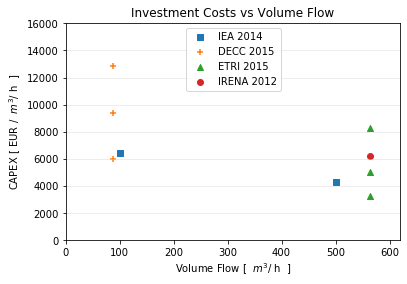

```python
# Total costs as a function of volume flow
fit = 0
tight = True
kind = 'CAPEX'
unit = 'volume'
plt_scatter_data(Size_v, CAPEX_v, paper, tight, kind, unit, fit)
plt.show()
```

[output not shown]

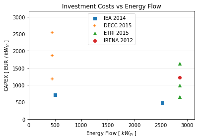

```python
# Total costs as a function of volume flow
fit = 0
tight = True
kind = 'CAPEX'
unit = 'energy'
plt_scatter_data(Size_q, CAPEX_q, paper, tight, kind, unit, fit)
plt.show()
```

## Boxplot as a function of volume flow in m$^3$/h

[output not shown]

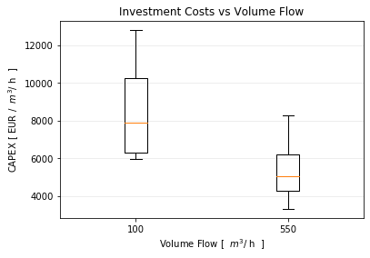

```python
# Investemnt costs as a function of volume flow
fit = 0
tight = True
kind = 'CAPEX'
unit = 'volume'
plt_boxplot_data(Size_v, CAPEX_v, paper, tight, kind, unit, fit)
plt.show()
```

[output not shown]

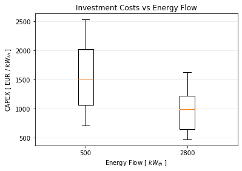

```python
# Investemnt costs as a function of energy flow
fit = 0
tight = True
kind = 'CAPEX'
unit = 'energy'
plt_boxplot_data(Size_q, CAPEX_q, paper, tight, kind, unit, fit)
plt.show()
```

[output not shown]

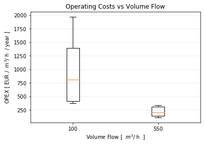

```python
# Operating costs as a function of volume flow
fit = 0
tight = True
kind = 'OPEX'
unit = 'volume'
plt_boxplot_data(Size_v, OPEX_v, paper, tight, kind, unit, fit)
plt.show()
```

[output not shown]

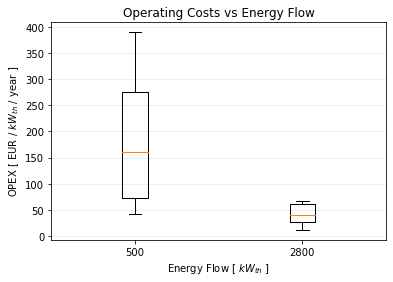

```python
# Operating costs as a function of energy flow
fit = 0
tight = True
kind = 'OPEX'
unit = 'energy'
plt_boxplot_data(Size_q, OPEX_q, paper, tight, kind, unit, fit)
plt.show()
```